# Data Mining Example

Author

Reese Locken

# 1 Introduction

The old saying goes: “There is no such thing as bad press.” I believe Boeing, Firestone, and Equifax would beg to differ, as would several of the entities in our data below.

In this data mining challenge, we will examine a dataset containing records of data breaches reported from 2004 to 2019. The breaches vary in size, type, and location.

We will clean and explore the dataset and use it to build a predictive model that business stakeholders can use to determine the potential impact of their own breach.

# 2 Understand Data

First, we must learn the essence of the dataset and generate a few ideas about what it can be used for.

Let’s take a look:

```r
kable(head(data, 1))
```

| Entity | alternative name | records lost | YEAR | story | SECTOR | METHOD | interesting story | DATA SENSITIVITY | DISPLAYED RECORDS | …11 | source name | 1st source link | 2nd source link |
| --- | --- | --- | --- | --- | --- | --- | --- | --- | --- | --- | --- | --- | --- |
| NA | NA | NA | year story broke | NA | web |  |  |  |  |  |  |  |  |

```r
kable(colnames(data), col.names = 'Column Names')
```

| Column Names |
| --- |
| Entity |
| alternative name |
| records lost |
| YEAR |
| story |
| SECTOR |
| METHOD |
| interesting story |
| DATA SENSITIVITY |
| DISPLAYED RECORDS |
| …11 |
| source name |
| 1st source link |
| 2nd source link |

```r
cat('The data has', dim(data)[1], 'rows and', dim(data)[2], 'columns.')
```

```
The data has 340 rows and 14 columns.
```

The data set appears to contain records of data breaches that have been reported on in the media. This could be useful to our organization in a few ways:

- We could examine breach patterns to see what we need to watch out for, especially in our own industry, with similar entities, and the types of data we are most obligated to protect.
- We could identify the types of breaches that put us at the highest risk of becoming an “interesting story” (not the kind of press we’re looking for!).
- We could select the reporting sources we should most closely watch to keep an eye on breach activity over time.

# 3 Prepare Data

Before we can work with our data, we need to clean it. Let’s look through what we have and fix any issues we find.

The first row appears to contain data definitions. We will list these and remove them from our data set.

**Data Definitions**

*YEAR*: year story broke

*sector*: web, healthcare, app, retail, gaming, transport, financial, tech government, telecoms, legal, media, academic, energy, military

*METHOD*: poor security, hacked, oops!, lost device, inside job

*DATA SENSITIVITY*:

1. Just email address/Online information

2 SSN/Personal details

3 Credit card information

4 Health & other personal records

5 Full details

*DISPLAYED RECORDS*: If records lost is greater than 100 million, then that value appears in this column. Otherwise, it is blank.

Now we can remove that row.

```r
rows_before_removal <- data |> summarize(N = n()) |> pull()

data <- data |>
          filter(!row_number() == 1)

rows_after_removal <- data |> summarize(N = n()) |> pull()

cat('Rows removed:', rows_before_removal - rows_after_removal, '\n')
```

```
Rows removed: 1
```

```r
cat('Rows remaining:', rows_after_removal)
```

```
Rows remaining: 339
```

Additionally, the eleventh column appears to be empty. Let’s confirm.

```r
data |>
  select(11) |>
  unique() |>
  pull()
```

```
[1] NA
```

Having confirmed that the eleventh column is empty, we will drop it.

```r
cols_before_removal <- length(colnames(data))

data <- data |>
          select(-11)

cols_after_removal <- length(colnames(data))

cat('Columns removed:', cols_before_removal - cols_after_removal, '\n')
```

```
Columns removed: 1
```

```r
cat('Columns remaining:', cols_after_removal)
```

```
Columns remaining: 13
```

Now let’s standardize the column names and make them easier to manipulate.

```r
data <- janitor::clean_names(data)

kable(colnames(data), col.names = 'Column Names')
```

| Column Names |
| --- |
| entity |
| alternative_name |
| records_lost |
| year |
| story |
| sector |
| method |
| interesting_story |
| data_sensitivity |
| displayed_records |
| source_name |
| x1st_source_link |
| x2nd_source_link |

With standardized column names, we can now check for nulls and data quality issues.

```r
kable(colSums(is.na(data)), col.names = c('Column', 'Null Count'))
```

| Column | Null Count |
| --- | --- |
| entity | 0 |
| alternative_name | 203 |
| records_lost | 1 |
| year | 0 |
| story | 0 |
| sector | 0 |
| method | 0 |
| interesting_story | 270 |
| data_sensitivity | 0 |
| displayed_records | 307 |
| source_name | 0 |
| x1st_source_link | 0 |
| x2nd_source_link | 307 |

Four columns have nulls for the majority of rows:

- alternative_name
- interesting_story
- displayed_records
- x2nd_source_link

Additionally, there is one missing row in records_lost. Let’s return to that.

In terms of null values, displayed_records is not a surprise, since it is explicitly programmed to only return a value when records_lost exceeds a certain value.

We will address those nulls in a moment. But first, let’s check out our data types and values.

```r
column_info <- data |>
  summarise_all(class) |>
  gather(key = "column_name", value = "data_type")

# Print the column information
kable(column_info)
```

| column_name | data_type |
| --- | --- |
| entity | character |
| alternative_name | character |
| records_lost | character |
| year | character |
| story | character |
| sector | character |
| method | character |
| interesting_story | character |
| data_sensitivity | character |
| displayed_records | character |
| source_name | character |
| x1st_source_link | character |
| x2nd_source_link | character |

Everything is currently stored as a character. That seems appropriate for most values, but I expect the following should be different:

- records_lost => integer
- year => time
- interesting_story => factor
- data_sensitivity => factor
- displayed_records => integer

Before changing these data types, let’s check if there are any inappropriate values that would prevent conversion.

We know that there is a null value in records_lost, so let’s start there.

```r
data |>
  filter(is.na(records_lost)) |>
  kable()
```

| entity | alternative_name | records_lost | year | story | sector | method | interesting_story | data_sensitivity | displayed_records | source_name | x1st_source_link | x2nd_source_link |
| --- | --- | --- | --- | --- | --- | --- | --- | --- | --- | --- | --- | --- |
| OVH | French Internet host | NA | 2013 | Jul 2013. A hacker was able to obtain access to an email account of a system administrator, then to the internal VPN of another employee, with which they were able to compromise the access of one of t… | web | hacked | NA | 2 | NA | OVH | http://status.ovh.net/?do=details&id=5070 | NA |

Upon visiting the provided link, the null appears to be valid. The report does not include any details on the number of records lost. We will keep this record unchanged.

What about records_lost?

```r
# Check all unique values in records_lost
data |>
  filter(str_detect(records_lost, "\\D")) |>
  group_by(records_lost) |>
  summarize(N = n()) |>
  arrange(desc(N)) |>
  kable()
```

| records_lost | N |
| --- | --- |
| ALL | 3 |
| 10M | 2 |
| 3M | 1 |
| <3000000 | 1 |
| <5000000 | 1 |

A few records contain values that cannot be converted easily to integers. Let’s address them one at a time.

```r
data |>
  filter(records_lost == 'ALL') |>
  kable()
```

| entity | alternative_name | records_lost | year | story | sector | method | interesting_story | data_sensitivity | displayed_records | source_name | x1st_source_link | x2nd_source_link |
| --- | --- | --- | --- | --- | --- | --- | --- | --- | --- | --- | --- | --- |
| Animoto | NA | ALL | 2019 | Feb 2019. Anomoto was part of the theft of 617 million online account details from 16 hacked websites, put up for sale on the dark web. | app | hacked | NA | 7 | NA | The Register | https://www.theregister.co.uk/2019/02/11/620_million_hacked_accounts_dark_web/ | NA |
| CoffeeMeetsBagel | NA | ALL | 2019 | Feb 2019. CoffeeMeetsBagel was part of the theft of 617 million online account details from 16 hacked websites, put up for sale on the dark web. | web | hacked | NA | 1 | NA | The Register | https://www.theregister.co.uk/2019/02/11/620_million_hacked_accounts_dark_web/ | NA |
| Petflow | NA | ALL | 2019 | Feb 2019. Petflow was part of the theft of 127 million records from eight websites, by the same hacker who previously stole 617 million online account details from 16 other sites. All were put up for … | retail | poor security | NA | 1 | NA | Techcrunch | https://techcrunch.com/2019/02/14/hacker-strikes-again/ | NA |

For the “ALL” values, the text of the articles contains the counts we need:

- Animoto - 25 million
- CoffeeMeetsBagel - 6 million
- Petflow - 1 million

We’ll replace “ALL” with those values later.

```r
data |>
  filter(records_lost %in% c("<3000000", "<5000000")) |>
  kable()
```

| entity | alternative_name | records_lost | year | story | sector | method | interesting_story | data_sensitivity | displayed_records | source_name | x1st_source_link | x2nd_source_link |
| --- | --- | --- | --- | --- | --- | --- | --- | --- | --- | --- | --- | --- |
| Saks and Lord & Taylor | Both owned by Hudson’s Bay Company | <5000000 | 2018 | Apr 2018. A known ring of cybercriminals implanted software into store cash registers, siphoning off payment card details. The company has not divulged the full extent of the breach. Researchers estim… | retail | hacked | NA | 3 | NA | NYTimes | https://www.nytimes.com/2018/04/01/technology/saks-lord-taylor-credit-cards.html | NA |
| Health South East | Health authority responsible for 10 Norwegian counties. | <3000000 | 2018 | Feb 2018. Health data was stolen from more than half of Norway’s population. | healthcare | hacked | NA | 4 | NA | It Governance | https://www.itgovernance.eu/blog/en/breach-at-norways-largest-healthcare-authority-was-a-disaster-waiting-to-happen | NA |

These articles do not contain values we can impute. However, based on the fact that “up to” estimates are often near the true value (e.g. you say “we’re in the top 10” if you’re ranked ninth, not “we’re in the top 20”), I think it is safe to impute the values provided minus one.

Thus, we can now replace our text values with integers and change the data type.

```r
num_rows_to_change <- data |>
  filter(str_detect(records_lost, "\\D")) |>
  summarize(N = n()) |>
  pull()

data <- data |>
          mutate(records_lost = case_when(
                (records_lost == 'ALL' & entity == 'Animoto') ~ 25000000,
                (records_lost == 'ALL' & entity == 'CoffeeMeetsBagel') ~ 6000000,
                (records_lost == 'ALL' & entity == 'Petflow') ~ 1000000,
                records_lost == '10M' ~ 10000000,
                records_lost == '3M' ~ 3000000,
                records_lost == '<5000000' ~ 5000000 - 1,
                records_lost == '<3000000' ~ 3000000 - 1,
                TRUE ~ as.integer(records_lost)
              ))

cat('Rows affected:', num_rows_to_change)
```

```
Rows affected: 8
```

Next, let’s check our year variable.

```r
data |>
  group_by(year) |>
  summarize(N = n()) |>
  kable()
```

| year | N |
| --- | --- |
| 1999 | 1 |
| 2004 | 1 |
| 2005 | 3 |
| 2006 | 5 |
| 2007 | 10 |
| 2008 | 21 |
| 2009 | 10 |
| 2010 | 15 |
| 2011 | 37 |
| 2012 | 23 |
| 2013 | 35 |
| 2014 | 19 |
| 2015 | 24 |
| 2016 | 33 |
| 2017 | 25 |
| 2018 | 44 |
| 2019 | 33 |

There are no problematic values here, so we can change it to a date.

```r
data <- data |>
  mutate(year = year(ymd(paste0(year, "-01-01"))))
```

Let’s handle interesting_story next. We can replace the current variables with more descriptive ones.

```r
data |>
  group_by(interesting_story) |>
  summarize(N = n()) |>
  kable()
```

| interesting_story | N |
| --- | --- |
| y | 69 |
| NA | 270 |

```r
data <- data |>
          mutate(interesting_story = factor(ifelse(is.na(interesting_story),
                                                   'No', 'Yes'),
                                        levels = c('No', 'Yes')))
```

data_sensitivity has an unexpected value. Let’s investigate before converting.

```r
data |>
  group_by(data_sensitivity) |>
  summarize(N = n()) |>
  kable()
```

| data_sensitivity | N |
| --- | --- |
| 1 | 108 |
| 2 | 101 |
| 3 | 49 |
| 4 | 55 |
| 5 | 25 |
| 7 | 1 |

```r
data |>
  filter(data_sensitivity == '7') |>
  kable()
```

| entity | alternative_name | records_lost | year | story | sector | method | interesting_story | data_sensitivity | displayed_records | source_name | x1st_source_link | x2nd_source_link |
| --- | --- | --- | --- | --- | --- | --- | --- | --- | --- | --- | --- | --- |
| Animoto | NA | 2.5e+07 | 2019 | Feb 2019. Anomoto was part of the theft of 617 million online account details from 16 hacked websites, put up for sale on the dark web. | app | hacked | No | 7 | NA | The Register | https://www.theregister.co.uk/2019/02/11/620_million_hacked_accounts_dark_web/ | NA |

```r
data |>
  filter(x1st_source_link == 'https://www.theregister.co.uk/2019/02/11/620_million_hacked_accounts_dark_web/') |>
  kable()
```

| entity | alternative_name | records_lost | year | story | sector | method | interesting_story | data_sensitivity | displayed_records | source_name | x1st_source_link | x2nd_source_link |
| --- | --- | --- | --- | --- | --- | --- | --- | --- | --- | --- | --- | --- |
| Dubsmash | NA | 1.62e+08 | 2019 | Feb 2019. Dubsmash was part of the theft of 617 million online account details from 16 hacked websites, put up for sale on the dark web. | app | hacked | No | 1 | 162000000 | The Register | https://www.theregister.co.uk/2019/02/11/620_million_hacked_accounts_dark_web/ | NA |
| ShareThis | NA | 4.10e+07 | 2019 | Feb 2019. ShareThis was part of the theft of 617 million online account details from 16 hacked websites, put up for sale on the dark web. | web | hacked | No | 1 | NA | The Register | https://www.theregister.co.uk/2019/02/11/620_million_hacked_accounts_dark_web/ | NA |
| HauteLook | NA | 2.80e+07 | 2019 | Feb 2019. HauteLook was part of the theft of 617 million online account details from 16 hacked websites, put up for sale on the dark web. | retail | hacked | No | 1 | NA | The Register | https://www.theregister.co.uk/2019/02/11/620_million_hacked_accounts_dark_web/ | NA |
| Animoto | NA | 2.50e+07 | 2019 | Feb 2019. Anomoto was part of the theft of 617 million online account details from 16 hacked websites, put up for sale on the dark web. | app | hacked | No | 7 | NA | The Register | https://www.theregister.co.uk/2019/02/11/620_million_hacked_accounts_dark_web/ | NA |
| EyeEm | NA | 2.20e+07 | 2019 | Feb 2019. EyeEm was part of the theft of 617 million online account details from 16 hacked websites, put up for sale on the dark web. | web | hacked | No | 1 | NA | The Register | https://www.theregister.co.uk/2019/02/11/620_million_hacked_accounts_dark_web/ | NA |
| 8fit | NA | 2.00e+07 | 2019 | Feb 2019. 8fit was part of the theft of 617 million online account details from 16 hacked websites, put up for sale on the dark web. | app | hacked | No | 1 | NA | The Register | https://www.theregister.co.uk/2019/02/11/620_million_hacked_accounts_dark_web/ | NA |
| Whitepages | NA | 1.80e+07 | 2019 | Feb 2019. Whitepages was part of the theft of 617 million online account details from 16 hacked websites, put up for sale on the dark web. | web | hacked | No | 1 | NA | The Register | https://www.theregister.co.uk/2019/02/11/620_million_hacked_accounts_dark_web/ | NA |
| Fotolog | NA | 3.00e+06 | 2019 | Feb 2019. Fotolog was part of the theft of 617 million online account details from 16 hacked websites, put up for sale on the dark web. | web | hacked | No | 1 | NA | The Register | https://www.theregister.co.uk/2019/02/11/620_million_hacked_accounts_dark_web/ | NA |
| Armor Games | NA | 1.10e+07 | 2019 | Feb 2019. Armor Games was part of the theft of 617 million online account details from 16 hacked websites, put up for sale on the dark web. | gaming | hacked | No | 1 | NA | The Register | https://www.theregister.co.uk/2019/02/11/620_million_hacked_accounts_dark_web/ | NA |
| BookMate | NA | 8.00e+06 | 2019 | Feb 2019. BookMate was part of the theft of 617 million online account details from 16 hacked websites, put up for sale on the dark web. | web | hacked | No | 1 | NA | The Register | https://www.theregister.co.uk/2019/02/11/620_million_hacked_accounts_dark_web/ | NA |
| CoffeeMeetsBagel | NA | 6.00e+06 | 2019 | Feb 2019. CoffeeMeetsBagel was part of the theft of 617 million online account details from 16 hacked websites, put up for sale on the dark web. | web | hacked | No | 1 | NA | The Register | https://www.theregister.co.uk/2019/02/11/620_million_hacked_accounts_dark_web/ | NA |
| Artsy | NA | 1.00e+06 | 2019 | Feb 2019. Artsy was part of the theft of 617 million online account details from 16 hacked websites, put up for sale on the dark web. | web | hacked | No | 1 | NA | The Register | https://www.theregister.co.uk/2019/02/11/620_million_hacked_accounts_dark_web/ | NA |
| DataCamp | NA | 7.00e+05 | 2019 | Feb 2019. DataCamp was part of the theft of 617 million online account details from 16 hacked websites, put up for sale on the dark web. | web | hacked | No | 1 | NA | The Register | https://www.theregister.co.uk/2019/02/11/620_million_hacked_accounts_dark_web/ | NA |

All other breaches from that same source have data_sensitivity = 1. So we will change the 7 to 1 for this record.

```r
num_rows_change <- data |>
                      filter(data_sensitivity == '7') |>
                      summarize(N = n()) |>
                      pull()

data <- data |>
            mutate(data_sensitivity = factor(ifelse(data_sensitivity == '7', 1,
                                                    data_sensitivity),
                                      levels = c('1', '2', '3', '4', '5')))
cat('Rows affected:', num_rows_change)
```

```
Rows affected: 1
```

Finally, because displayed_records is based on a rule, we can simply re-create the rule to populate the column.

```r
data <- data |>
          mutate(displayed_records = ifelse(records_lost > 100000000,
                                            records_lost, NA))
```

Let’s clean up the other columns. I have removed some of my exploratory code, but the process for each column was the same: I harmonized similar values under one category (e.g. Snapchat) and checked article links to determine appropriate categories.

```r
# Clean entity

data <- data |>
          mutate(entity = gsub('"','', entity)) |>
          mutate(entity = gsub('Snapchat', 'SnapChat', entity)) |>
          mutate(entity = ifelse(entity == 'US Office of Personnel Management (2nd Breach)', 'US Office of Personnel Management', entity)) |>
          # This record appears to be a duplicate of the LinkedIn and Last.fm breaches, with no data about eHarmony's count of lost passwords
          filter(entity != 'LinkedIn, eHarmony, Last.fm')


# Clean story

data <- data |>
        # This is a duplicate story, with a less accurate count of lost documents
        # I have retained the other record and credited the story to The Guardian
        filter(alternative_name != 'Wikileaks / Bradley Manning/Cablegate.' | is.na(alternative_name)) |>
        mutate(source_name = ifelse(source_name == 'Guardian, Wikileaks', 'Guardian', source_name))


# Clean source_name
# If there were two listed sources, I chose to credit the first listed source
# One could also split the source_name column into two: source_1 and source_2

data <- data |>
        mutate(source_name = ifelse(source_name == 'Guardian', 'The Guardian', source_name)) |>
        mutate(source_name = ifelse(source_name == 'ZD Net', 'ZDNet', source_name)) |>
        mutate(source_name = ifelse(source_name == 'Washington-Post', 'Washington Post', source_name)) |>
        mutate(source_name = ifelse(source_name %in% c('NY Times', 'NY Times, Gov Tech'), 'NYTimes', source_name)) |>
        mutate(source_name = ifelse(source_name %in% c('Wired, CBNC', 'Wired, Digital Trends'), 'Wired', source_name)) |>
        mutate(source_name = ifelse(source_name %in% c('Naked Security, NBC News', 'Naked Security, New York Times'), 'NYTimes', source_name)) |>
        mutate(source_name = ifelse(source_name %in% c('Computer World, Hacker News'), 'Computer World', source_name)) |>
        mutate(source_name = ifelse(source_name %in% c('Korea Times, CNet'), 'Korea Times', source_name)) |>
        mutate(source_name = ifelse(source_name %in% c('NBC29'), 'NBC', source_name)) |>
        mutate(source_name = ifelse(source_name %in% c('Reuters, Privacy Rights'), 'Reuters', source_name)) |>
        mutate(source_name = ifelse(source_name == 'GCN, US Gov', 'GCN', source_name))

# Clean sector

# Aggregate smaller sectors to their most logical parent

data <- data |>
  mutate(sector = ifelse(sector == 'government, military', 'government', sector)) |>
  mutate(sector = ifelse(sector == 'government, healthcare', 'government', sector)) |>
  mutate(sector = ifelse(sector == 'military, healthcare', 'healthcare', sector)) |>
  mutate(sector = ifelse(sector == 'web, military', 'web', sector)) |>
  mutate(sector = ifelse(sector == 'web, gaming', 'web', sector)) |>
  mutate(sector = ifelse(sector == 'tech, app', 'tech', sector)) |>
  mutate(sector = ifelse(sector == 'web, tech', 'tech', sector)) |>
  mutate(sector = ifelse(sector == 'tech, retail', 'retail', sector)) |>
  mutate(sector = ifelse(sector == 'tech, web', 'web', sector)) |>
  mutate(sector = ifelse(sector == 'legal', 'financial', sector))


# Clean year

data <- data |>
  # Per the article, the breach is actually from 2019
  mutate(year = ifelse(year == 1999, 2019, year))

cat('Cleaned data contains', dim(data)[1], 'rows and', dim(data)[2], 'columns.')
```

```
Cleaned data contains 337 rows and 13 columns.
```

# 4 Explore Data

Now that our data has been cleaned, we can begin exploring it. We can check univariate and bivariate distributions to look for patterns which can guide the product we end up creating.

Let’s start asking questions of our data!

**What is the distribution of records_lost?**

Records_lost appears to follow a power distribution. We can see that the distribution normalizes nicely when log transformed. Despite a slight uptick towards the extreme high numbers, checking the articles confirms that the counts are correct.

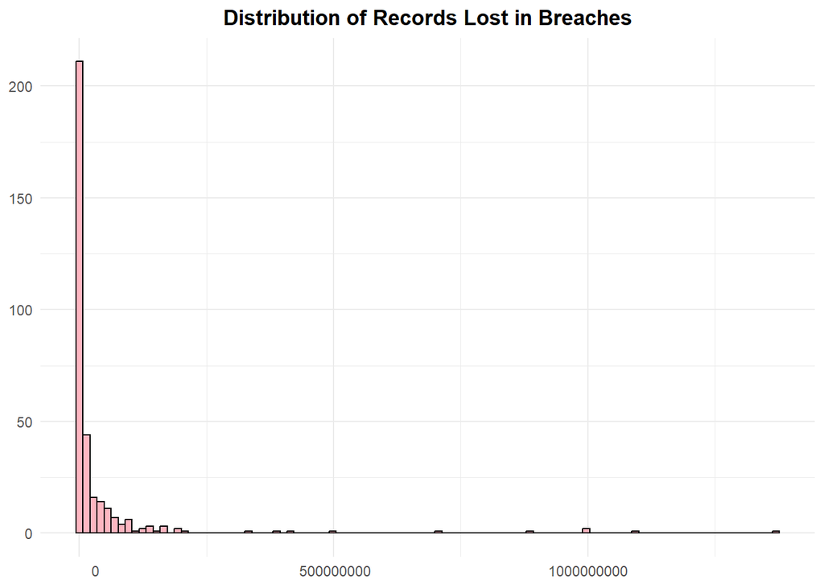

```r
data |>
  ggplot(aes(x = records_lost)) +
  geom_histogram(fill = 'lightpink', color = 'black', bins = 100) +
  theme_minimal() +
  labs(title = 'Distribution of Records Lost in Breaches') +
  theme(plot.title = element_text(hjust = 0.5, face = 'bold'),
        axis.title = element_blank()) +
  scale_x_continuous(labels = ~ format(.x, scientific = FALSE))
```

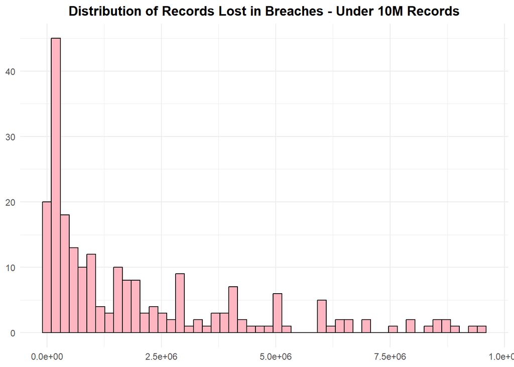

```r
data |>
  filter(records_lost < 10000000) |>
  ggplot(aes(x = records_lost)) +
  geom_histogram(bins = 50, fill = 'lightpink', color = 'black') +
  theme_minimal() +
  labs(title = 'Distribution of Records Lost in Breaches - Under 10M Records') +
  theme(plot.title = element_text(hjust = 0.5, face = 'bold'),
        axis.title = element_blank())
```

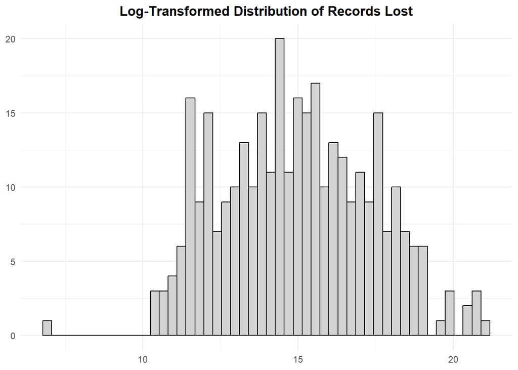

```r
data |>
  ggplot(aes(x = log(records_lost))) +
  geom_histogram(fill = 'lightgrey', color = 'black', bins = 50) +
  theme_minimal() +
  labs(title = 'Log-Transformed Distribution of Records Lost') +
  theme(plot.title = element_text(hjust = 0.5, face = 'bold'),
        axis.title = element_blank()) +
  scale_x_continuous(labels = ~ format(.x, scientific = FALSE))
```

```r
data |>
  arrange(desc(records_lost)) |>
  select(entity, records_lost, sector, x1st_source_link) |>
  head(5) |>
  kable()
```

| entity | records_lost | sector | x1st_source_link |
| --- | --- | --- | --- |
| River City Media | 1.37e+09 | web | https://www.theguardian.com/technology/2017/mar/06/email-addresses-spam-leak-river-city-media |
| Aadhaar | 1.10e+09 | government | http://www.zdnet.com/article/another-data-leak-hits-india-aadhaar-biometric-database/ |
| Aadhaar | 1.00e+09 | government | https://www.theguardian.com/world/2018/jan/04/india-national-id-database-data-leak-bought-online-aadhaar |
| Yahoo | 1.00e+09 | web | http://www.nytimes.com/2016/12/14/technology/yahoo-hack.html?action=Click&contentCollection=BreakingNews&contentID=64651831&pgtype=Homepage&_r=0 |
| First American Financial Corporation | 8.85e+08 | financial | https://krebsonsecurity.com/2019/05/first-american-financial-corp-leaked-hundreds-of-millions-of-title-insurance-records/ |

```r
data |>
  arrange(desc(records_lost)) |>
  select(entity, records_lost, sector, x1st_source_link) |>
  tail(5) |>
  kable()
```

| entity | records_lost | sector | x1st_source_link |
| --- | --- | --- | --- |
| uTorrent | 35000 | web | https://torrentfreak.com/utorrent-forums-hacked-passwords-compromised-160608/ |
| Quest Diagnostics | 34000 | healthcare | http://newsroom.questdiagnostics.com/2016-12-12-Quest-Diagnostics-Provides-Notice-of-Data-Security-Incident#assets_129 |
| Morgan Stanley Smith Barney | 34000 | financial | https://abcnews.go.com/Business/morgan-stanley-smith-barney-breach-losing-client-data/story?id=14008632 |
| Wendy’s | 1025 | retail | https://www.forbes.com/sites/moneybuilder/2016/07/08/this-week-in-credit-card-news-wendys-data-breach-affects-1000-stores-card-fraud-dropping/#260a2f727bab |
| OVH | NA | web | http://status.ovh.net/?do=details&id=5070 |

However, at the low end following the link for Wendy’s indicates that 1,025 locations were exposed.

Taking the average annual gross sales of [$1,892,827](https://www.franchisechatter.com/2023/03/10/fdd-talk-wendys-franchise-costs-fees-average-revenues-and-or-profits-2023-review/) and assuming an average order size of $15, that gives us an average of about 10k customers per month. Assuming 50% are repeat customers and that the exposure lasted for three months, I will impute 20k customers per store, giving us an exposure of 20,500,000. This makes sense, as the article references a breach at Target that exposed 30 million customer records as a comparison.

```r
# Impute estimate of records_lost for Wendy's
data <- data |>
          mutate(records_lost = ifelse(entity == "Wendy's", 20500000, records_lost))
```

**Have the number of breaches changed over time?**

We see that breaches (or at least the reporting of breaches), has steadily increased. There is decent fluctuation from year-to-year, which might reflect ad-hoc reporting rather than true fluctuations in breach rates.

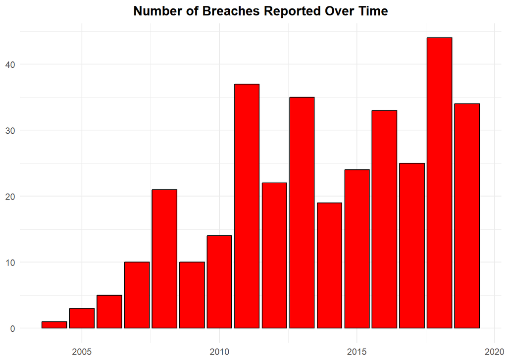

```r
data |>
  group_by(year) |>
  summarize(N = n()) |>
  ggplot(aes(x = year, y = N)) +
  geom_col(fill = 'red', color = 'black') +
  theme_minimal() +
  labs(title = 'Number of Breaches Reported Over Time') +
  theme(plot.title = element_text(hjust = 0.5, face = 'bold'),
        axis.title = element_blank())
```

**Have the number of records lost changed over time?**

Lost records follows a similar trend to breaches, with 2018 being a particularly bad year. However, stories for 2019 only appear to reach June 2019, so it’s likely our dataset cuts off at that point and 2019 actually had as many or more lost records than 2018.

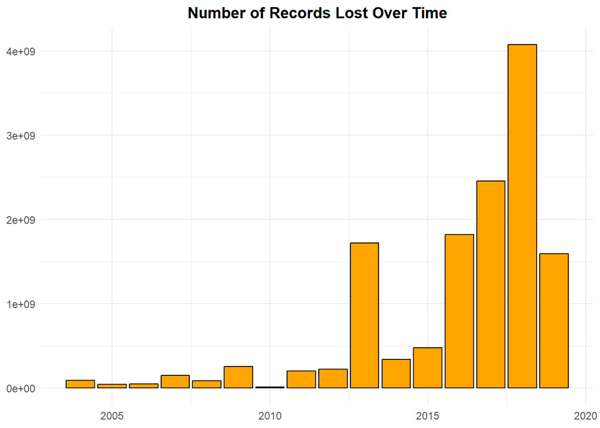

```r
data |>
  filter(!is.na(records_lost)) |>
  group_by(year) |>
  summarize(records = sum(records_lost)) |>
  ggplot(aes(x = year, y = records)) +
  geom_col(fill = 'orange', color = 'black') +
  theme_minimal() +
  labs(title = 'Number of Records Lost Over Time') +
  theme(plot.title = element_text(hjust = 0.5, face = 'bold'),
        axis.title = element_blank())
```

```r
data |>
  filter(year == 2019) |>
  mutate(extracted_month = str_extract(story, "^[^.]*")) |>
  select(extracted_month) |>
  unique() |>
  kable()
```

| extracted_month |
| --- |
| June 2019 |
| May 2019 |
| Apr 2019 |
| Mar 2019 |
| Feb 2019 |
| Jan 2019 |

**How has the average size of a breach changed over time?**

Interestingly, our average breach size does not show the same linear growth pattern. Perhaps large breaches take longer to organize, and thus don’t occur at annual intervals?

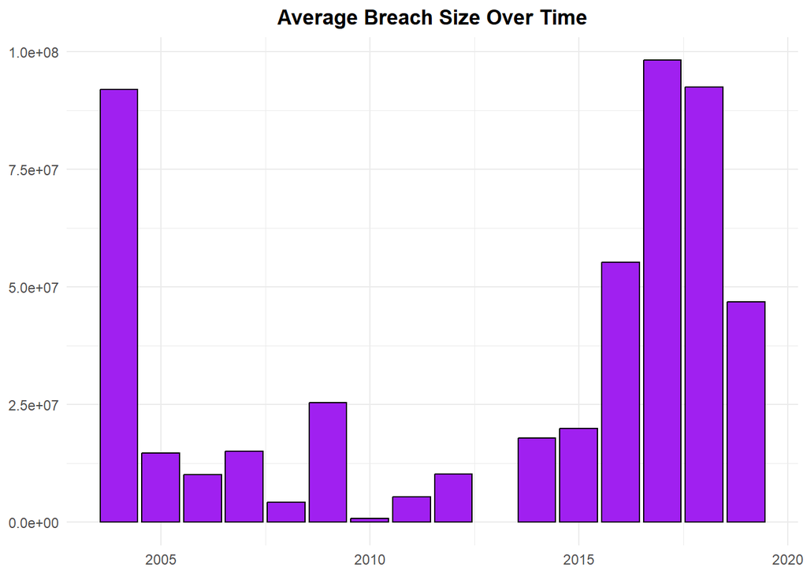

```r
data |>
  group_by(year) |>
  summarize(size = sum(records_lost) / n()) |>
  ggplot(aes(x = year, y = size)) +
  geom_col(fill = 'purple', color = 'black') +
  theme_minimal() +
  labs(title = 'Average Breach Size Over Time') +
  theme(plot.title = element_text(hjust = 0.5, face = 'bold'),
        axis.title = element_blank())
```

When we look at the largest breaches, we find that in fact they are not evenly distributed. The number of large breaches has increased over time. So not only are we getting more breaches, we are seeing larger ones on average and more very large ones. This is bad news!

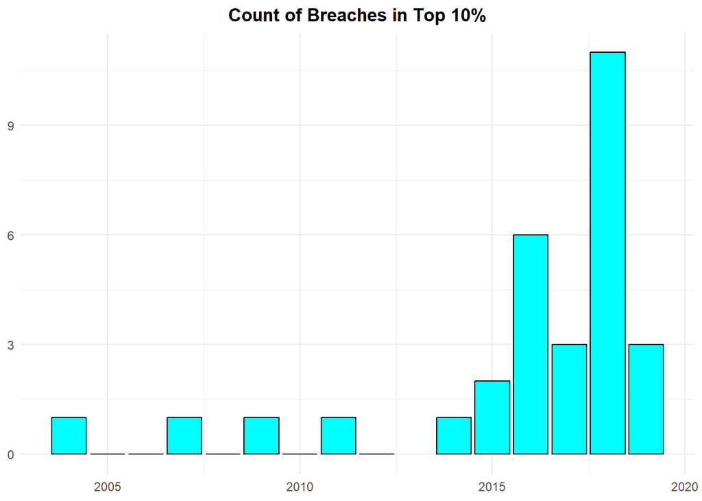

```r
data |>
  mutate(large_breach = ifelse(records_lost > 76000000, 1, 0)) |>
  group_by(year) |>
  summarize(large_breaches = sum(large_breach)) |>
  ggplot(aes(x = year, y = large_breaches)) +
  geom_col(fill = 'cyan', color = 'black') +
  theme_minimal() +
  labs(title = 'Count of Breaches in Top 10%') +
  theme(plot.title = element_text(hjust = 0.5, face = 'bold'),
        axis.title = element_blank())
```

**Have certain methods become more popular?**

We see that the largest increases in breaches have come from hacks and poor security. This has business implications: perhaps we should rethink our current level of investment in cybersecurity?

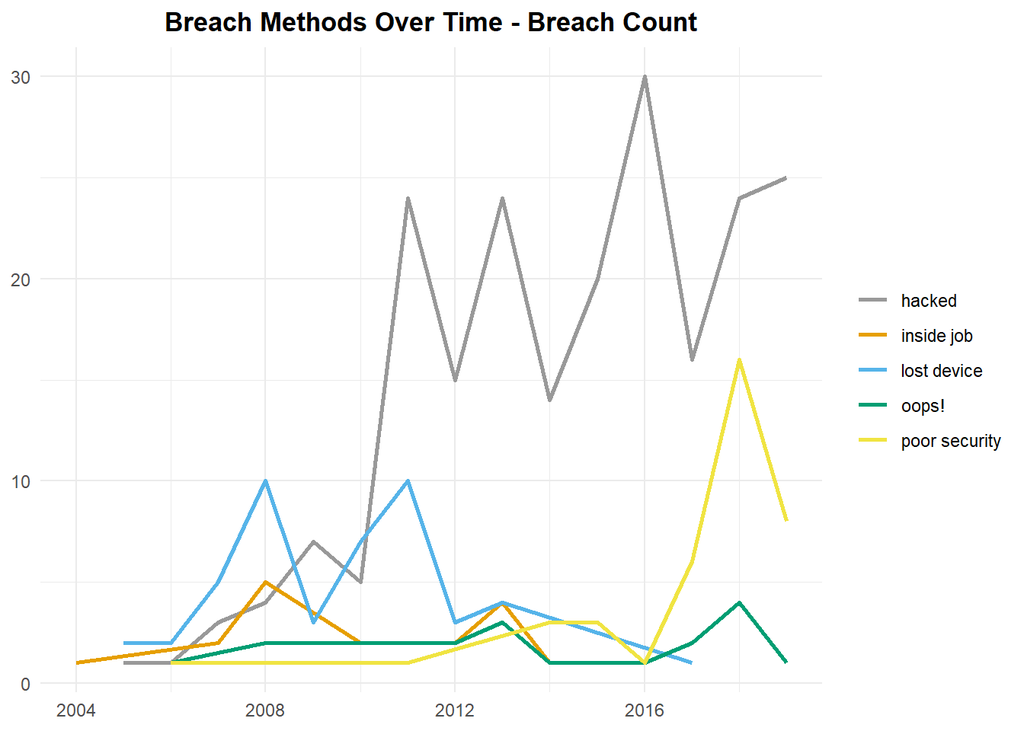

```r
# Colorblind palette
cbPalette <- c("#999999", "#E69F00", "#56B4E9", "#009E73",
               "#F0E442", "#0072B2", "#D55E00", "#CC79A7")

# Breaches by method over time
data |>
  # filter(interesting_story == 'Yes') |>
  group_by(year, method) |>
  summarize(N = n(), .groups = 'drop') |>
  ggplot(aes(x = year, y = N, color = method)) +
  geom_line(linewidth = 1) +
  theme_minimal() +
  scale_color_manual(values = cbPalette) +
  labs(title = 'Breach Methods Over Time - Breach Count') +
  theme(plot.title = element_text(hjust = 0.5, face = 'bold'),
        axis.title = element_blank(),
        legend.title = element_blank())
```

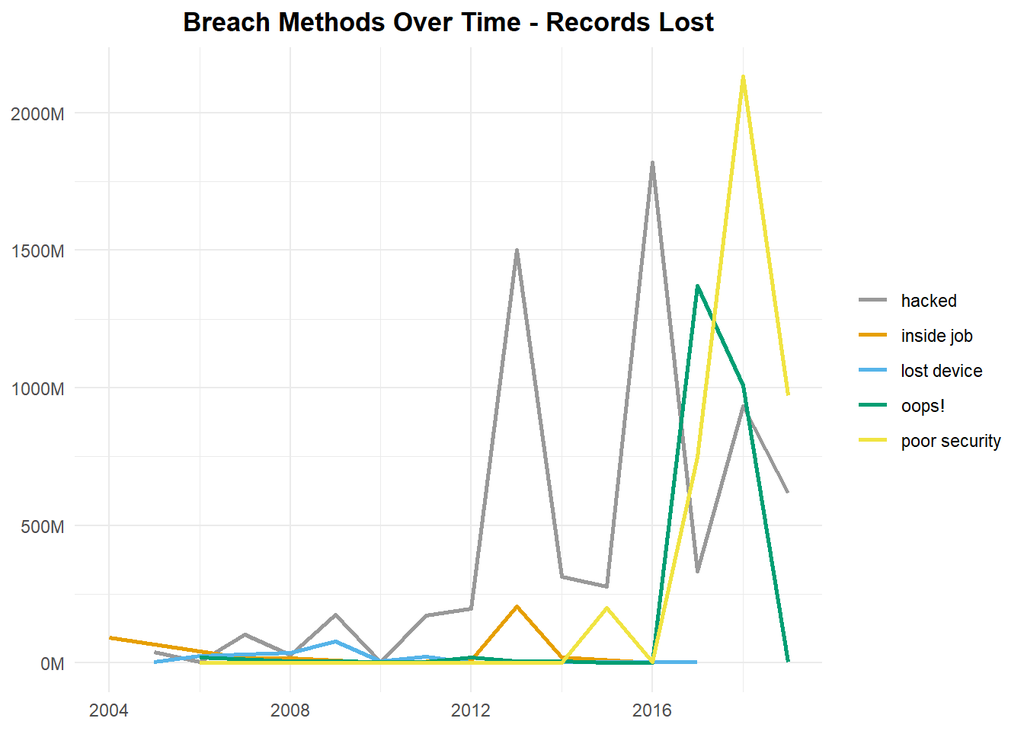

```r
# Records lost by method over time
data |>
  filter(!is.na(records_lost)) |>
  group_by(year, method) |>
  summarize(N = sum(records_lost), .groups = 'drop') |>
  ggplot(aes(x = year, y = N, color = method)) +
  geom_line(linewidth = 1) +
  theme_minimal() +
  scale_color_manual(values = cbPalette) +
  scale_y_continuous(labels = function(x) paste0(round(x / 1e6, 1), "M")) +
  labs(title = 'Breach Methods Over Time - Records Lost') +
  theme(plot.title = element_text(hjust = 0.5, face = 'bold'),
        axis.title = element_blank(),
        legend.title = element_blank())
```

**Who are the biggest breach victims?**

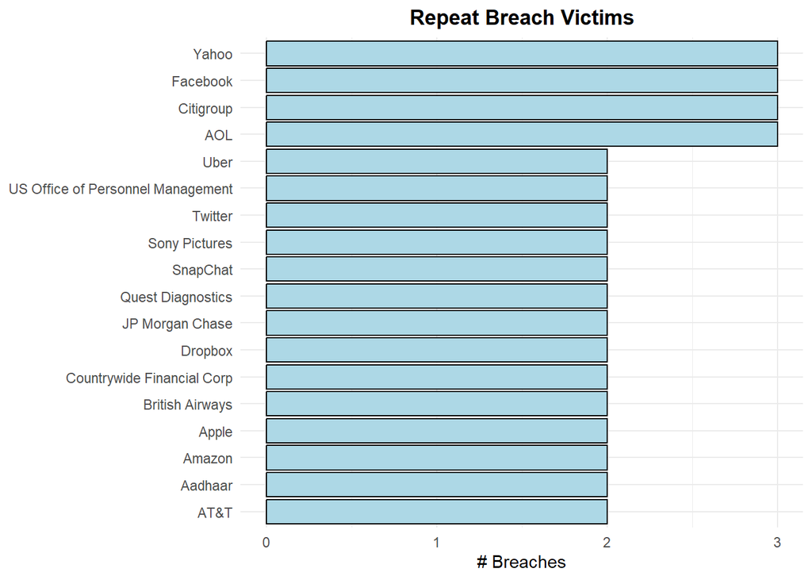

```r
data |>
  group_by(entity) |>
  summarize(N = n(), .groups = 'drop') |>
  filter(N > 1) |>
  arrange(N) |>
  mutate(entity = factor(entity, levels = unique(entity))) |>
  ggplot(aes(x = N, y = entity)) +
  geom_col(fill = 'lightblue', color = 'black') +
  theme_minimal() +
  labs(title = 'Repeat Breach Victims',
       x = '# Breaches') +
  theme(plot.title = element_text(hjust = 0.5, face = 'bold'),
        axis.title.y = element_blank())
```

## 4.1 Interesting Stories - A PR Nightmare?

Certain breaches have been classified as “interesting stories”. Presumably, this kind of story is more likely to get picked up and shared, resulting in bad press for our organization. As such, they are best avoided. Let’s see what we can learn about the characteristics of these stories to make sure we don’t become one.

**Does the size of the breach correlate with interesting_story?**

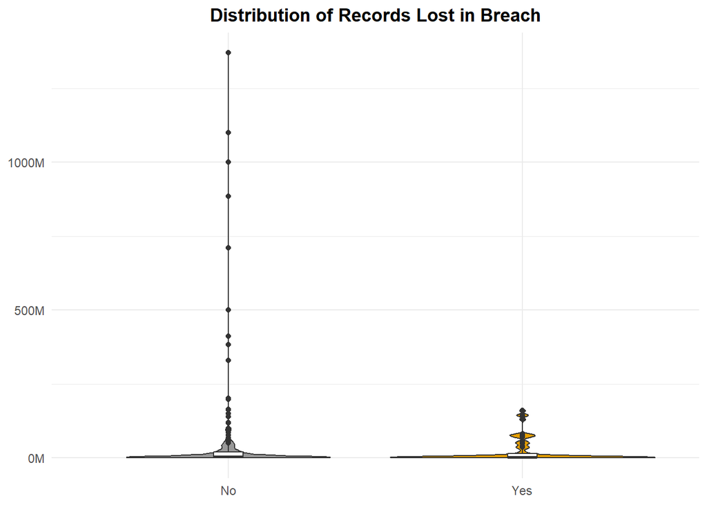

```r
options(scipen=999)

data |>
  ggplot(aes(x = interesting_story, y = records_lost, fill = interesting_story)) +
  geom_violin() +
  geom_boxplot(width = 0.1, fill = 'white') +
  ylim(0,10000000) +
  theme_minimal() +
  labs(title = 'Distribution of Records Lost in Breach') +
  scale_y_continuous(labels = function(x) paste0(round(x / 1e6, 1), "M")) +
  theme(plot.title = element_text(hjust = 0.5, face = 'bold'),
        axis.title = element_blank(),
        legend.position = 'none') +
  scale_fill_manual(values = cbPalette)
```

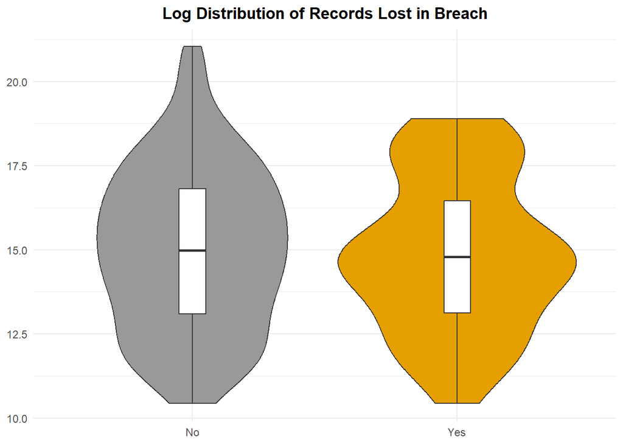

```r
data |>
  ggplot(aes(x = interesting_story, y = log(records_lost), fill = interesting_story)) +
  geom_violin() +
  geom_boxplot(width = 0.1, fill = 'white') +
  # ylim(0,10000000) +
  theme_minimal() +
  labs(title = 'Log Distribution of Records Lost in Breach') +
  theme(plot.title = element_text(hjust = 0.5, face = 'bold'),
        axis.title = element_blank(),
        legend.position = 'none') +
  scale_fill_manual(values = cbPalette)
```

```r
# Conduct Mann-Whitney U test to identify whether the difference is significant

group1 <- data |> filter(interesting_story == 'Yes') |> select(records_lost) |> pull()

group2 <- data |> filter(interesting_story == 'No') |> select(records_lost) |> pull()

# Conducting the Mann-Whitney U test
test_result <- wilcox.test(group1, group2, alternative = "two.sided")

# Printing the test results
print(test_result)
```

```
    Wilcoxon rank sum test with continuity correction

data:  group1 and group2
W = 8864, p-value = 0.7294
alternative hypothesis: true location shift is not equal to 0
```

**Does the source correlate with interesting_story?**

Still, no strong pattern emerges that certain publications are more likely to have interesting stories. So sending a box of cigars to the chief editor of Wired isn’t going to cut it.

```r
# Create table with interesting story counts by source

data |>
  group_by(interesting_story,source_name) |>
  summarize(N = n(), .groups = 'drop') |>
  pivot_wider(names_from = interesting_story, values_from = N) |>
  mutate(No = ifelse(is.na(No), 0, No),
         Yes = ifelse(is.na(Yes), 0, Yes),
    total = No + Yes,
    pct_sig = Yes / total) |>
  arrange(desc(Yes)) |>
  head(20) |>
  kable()
```

| source_name | No | Yes | total | pct_sig |
| --- | --- | --- | --- | --- |
| The Guardian | 19 | 5 | 24 | 0.2083333 |
| Computer World | 1 | 3 | 4 | 0.7500000 |
| BBC News | 11 | 2 | 13 | 0.1538462 |
| Business Insider | 3 | 2 | 5 | 0.4000000 |
| CNN | 4 | 2 | 6 | 0.3333333 |
| Computer Weekly | 3 | 2 | 5 | 0.4000000 |
| Krebs on Security | 4 | 2 | 6 | 0.3333333 |
| NYTimes | 8 | 2 | 10 | 0.2000000 |
| Reuters | 9 | 2 | 11 | 0.1818182 |
| Tech Crunch | 3 | 2 | 5 | 0.4000000 |
| Washington Post | 3 | 2 | 5 | 0.4000000 |
| Wired | 4 | 2 | 6 | 0.3333333 |
| Info Watch | 0 | 2 | 2 | 1.0000000 |
| Mashable | 0 | 2 | 2 | 1.0000000 |
| ABC News | 3 | 1 | 4 | 0.2500000 |
| Ars Technica | 1 | 1 | 2 | 0.5000000 |
| CNET | 1 | 1 | 2 | 0.5000000 |
| CNet | 1 | 1 | 2 | 0.5000000 |
| Dark Reading | 1 | 1 | 2 | 0.5000000 |
| Data Breaches | 8 | 1 | 9 | 0.1111111 |

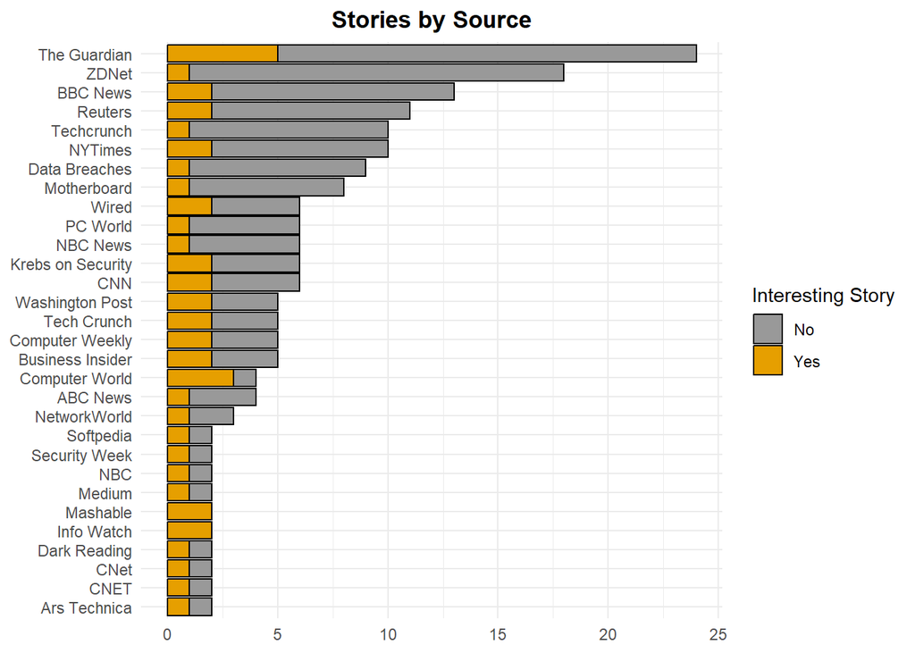

```r
# Visualize counts for all sources with at least one story

# Filter to sources with at least one interesting story
interesting_sources <- data |>
  filter(interesting_story == 'Yes') |>
  select(source_name) |>
  unique() |> pull()

# Filter to sources with more than one story total
multiple_stories <- data |>
  group_by(source_name) |>
  summarize(N = n(), .groups = 'drop') |>
  filter(N > 1) |>
  select(source_name) |>
  pull()


data_filtered <- data |>
  filter(source_name %in% interesting_sources) |>
  filter(source_name %in% multiple_stories) |>
  group_by(source_name) |>
  summarize(N = n(), .groups = 'drop') |>
  arrange(N)

# Reorder source_name factor levels
data_filtered$source_name <- factor(data_filtered$source_name, levels = data_filtered$source_name)

# Merge back the filtered data with the reordered factor levels
data_reordered <- data |>
  filter(source_name %in% interesting_sources) |>
  filter(source_name %in% multiple_stories) |>
  mutate(source_name = factor(source_name, levels = levels(data_filtered$source_name)))

# Plot
ggplot(data_reordered, aes(y = source_name, fill = interesting_story)) +
  geom_bar(color = 'black') +
  labs(x = "Count", y = "Source Name", fill = "Interesting Story") +
  theme_minimal() +
  scale_fill_manual(values = cbPalette) +
  labs(title = 'Stories by Source') +
  theme(plot.title = element_text(hjust = 0.5, face = 'bold'),
        axis.title = element_blank())
```

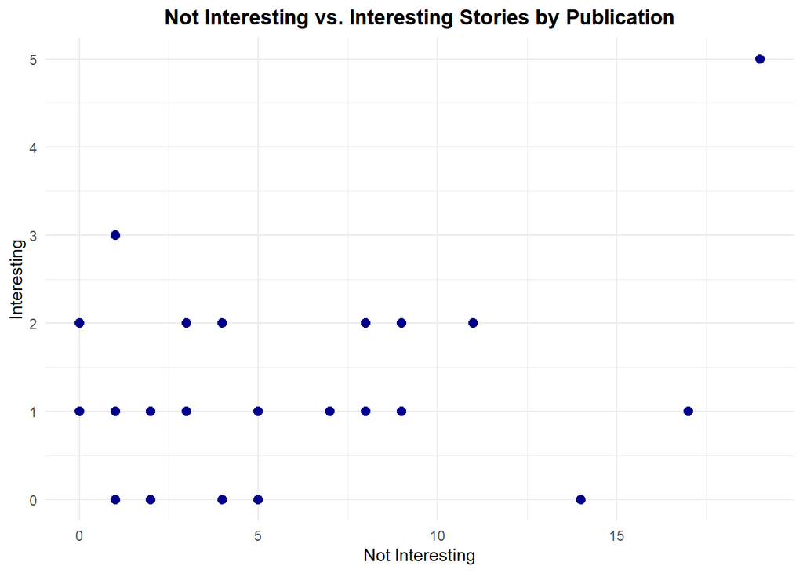

```r
# Visualize relationship between interesting and not interesting story counts

data |>
  group_by(interesting_story,source_name) |>
  summarize(N = n(), .groups = 'drop') |>
  pivot_wider(names_from = interesting_story, values_from = N) |>
  mutate(No = ifelse(is.na(No), 0, No),
         Yes = ifelse(is.na(Yes), 0, Yes),
    Total = No + Yes,
    prop_interesting = Yes / Total) |>
  ggplot(aes(x = No, y = Yes)) +
  geom_point(size = 2.5, color = 'darkblue') +
  theme_minimal() +
  labs(title = 'Not Interesting vs. Interesting Stories by Publication',
       x = 'Not Interesting',
       y = 'Interesting') +
  theme(plot.title = element_text(hjust = 0.5, face = 'bold'),
        legend.position = 'none')
```

```r
# Get table showing proportion of all interesting stories by source

data |>
  filter(interesting_story == 'Yes') |>
  group_by(source_name) |>
  summarize(N = n(), .groups = 'drop') |>
  mutate(prop = N / sum(N)) |>
  arrange(desc(prop)) |>
  kable()
```

| source_name | N | prop |
| --- | --- | --- |
| The Guardian | 5 | 0.0735294 |
| Computer World | 3 | 0.0441176 |
| BBC News | 2 | 0.0294118 |
| Business Insider | 2 | 0.0294118 |
| CNN | 2 | 0.0294118 |
| Computer Weekly | 2 | 0.0294118 |
| Info Watch | 2 | 0.0294118 |
| Krebs on Security | 2 | 0.0294118 |
| Mashable | 2 | 0.0294118 |
| NYTimes | 2 | 0.0294118 |
| Reuters | 2 | 0.0294118 |
| Tech Crunch | 2 | 0.0294118 |
| Washington Post | 2 | 0.0294118 |
| Wired | 2 | 0.0294118 |
| ABC News | 1 | 0.0147059 |
| Adobe | 1 | 0.0147059 |
| Alphr | 1 | 0.0147059 |
| Ars Technica | 1 | 0.0147059 |
| Boing Boing, Wired | 1 | 0.0147059 |
| CNET | 1 | 0.0147059 |
| CNet | 1 | 0.0147059 |
| ComputerSweden | 1 | 0.0147059 |
| Dark Reading | 1 | 0.0147059 |
| Data Breaches | 1 | 0.0147059 |
| Deal Book | 1 | 0.0147059 |
| Digital Health | 1 | 0.0147059 |
| Flanders Today | 1 | 0.0147059 |
| Fosters | 1 | 0.0147059 |
| Guelph Mercury | 1 | 0.0147059 |
| Health IT Security | 1 | 0.0147059 |
| Huffington Post | 1 | 0.0147059 |
| Medium | 1 | 0.0147059 |
| Motherboard | 1 | 0.0147059 |
| NBC | 1 | 0.0147059 |
| NBC News | 1 | 0.0147059 |
| NetworkWorld | 1 | 0.0147059 |
| PC World | 1 | 0.0147059 |
| PanamaPapers | 1 | 0.0147059 |
| Proskauer | 1 | 0.0147059 |
| Salt Lake Tribune | 1 | 0.0147059 |
| Security Week | 1 | 0.0147059 |
| Softpedia | 1 | 0.0147059 |
| Techcrunch | 1 | 0.0147059 |
| Technology Review | 1 | 0.0147059 |
| The Intercept | 1 | 0.0147059 |
| The Local | 1 | 0.0147059 |
| The Next Web | 1 | 0.0147059 |
| UK Gov | 1 | 0.0147059 |
| Wall Street Journal | 1 | 0.0147059 |
| ZDNet | 1 | 0.0147059 |

**Does the method of the breach correlate with interesting_story?**

Lost devices and oops! are over-represented as interesting stories. Perhaps because accidents like these stand out?

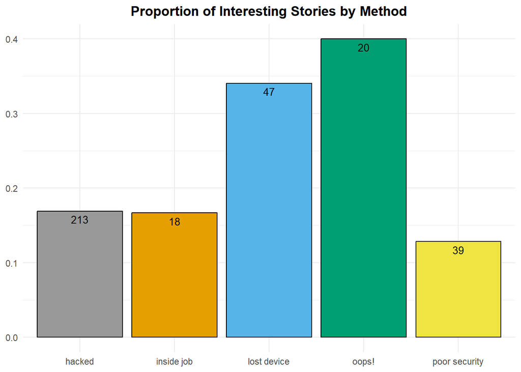

```r
data |>
  group_by(method) |>
  summarize(prop_interesting = mean(ifelse(interesting_story == 'Yes', 1, 0)),
            N = n()) |>
  ggplot(aes(x = method, y = prop_interesting, fill = method)) +
  geom_col(color = 'black') +
  geom_text(aes(label = N), vjust = 1.5, color = 'black', size = 3.5) +
  scale_fill_manual(values = cbPalette) +
  theme_minimal() +
  labs(title = 'Proportion of Interesting Stories by Method',
       x = 'Method',
       y = 'Proportion of Stories Rated Interesting') +
  theme(plot.title = element_text(hjust = 0.5, face = 'bold'),
        legend.position = 'none',
        axis.title = element_blank())
```

**Does the data sensitivity correlate with interesting_story?**

Data breaches that involve social security numbers, financial information, or all information are more likely to be rated as interesting. This is understandable, as the immediate consequences for consumers are greater.

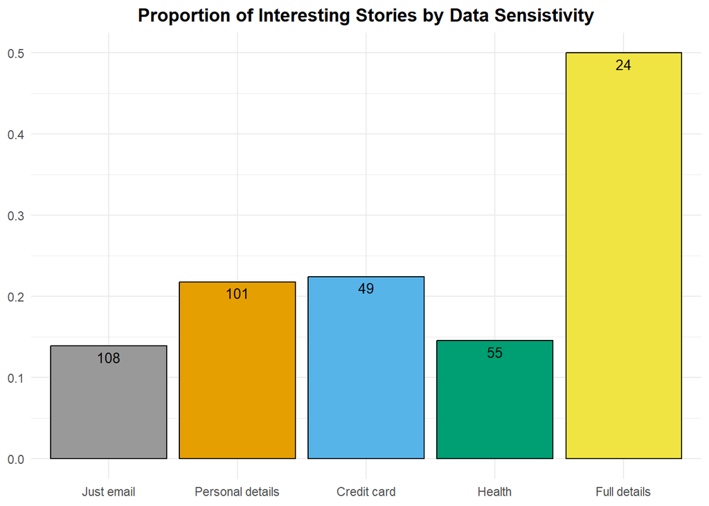

```r
data |>
  group_by(data_sensitivity) |>
  summarize(prop_interesting = mean(ifelse(interesting_story == 'Yes', 1, 0)),
            N = n()) |>
  ggplot(aes(x = data_sensitivity, y = prop_interesting, fill = data_sensitivity)) +
  geom_col(color = 'black') +
  geom_text(aes(label = N), vjust = 1.5, color = 'black', size = 3.5) +
  scale_fill_manual(values = cbPalette) +
  theme_minimal() +
  labs(title = 'Proportion of Interesting Stories by Data Sensistivity',
       x = 'Data Sensitivity',
       y = 'Proportion of Stories Rated Interesting') +
  theme(plot.title = element_text(hjust = 0.5, face = 'bold'),
        legend.position = 'none',
        axis.title = element_blank()) +
  scale_x_discrete(labels = c('Just email', 'Personal details','Credit card',
                              'Health', 'Full details'))
```

**Does the data sensitivity correlate with method?**

We see that hacks are most likely to obtain online information or personal details. This makes sense, as those are the fields most likely to be stored in a public-facing website.

The risk of full details being disclosed is highest from an inside job. This is also reasonable, because access to an internal database exposes much more data. When combined with the proportion of full-detail disclosures that are rated as interesting stories, we should review that internal data is locked down. Users should not be able to remove data from the system, either digitally or via external devices.

Fisher’s exact test allows us to reject the null hypothesis at alpha = 0.05 and conclude that there is an association between the method used and the sensitivity of the data exposed.

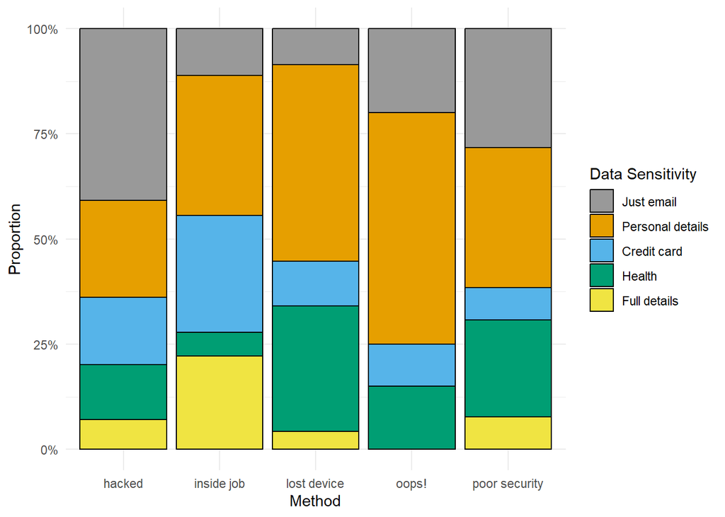

```r
# Group by and summarize, then calculate the proportions
data_normalized <- data |>
  group_by(method, data_sensitivity) |>
  summarize(N = n(), .groups = 'drop') |>
  group_by(method) |>
  mutate(Proportion = N / sum(N))

# Create the 100% stacked column chart
ggplot(data_normalized, aes(x = method, y = Proportion,
                            fill = data_sensitivity)) +
  geom_col(color = 'black') +
  scale_y_continuous(labels = scales::percent_format()) +
  labs(x = "Method", y = "Proportion", fill = "Data Sensitivity") +
  theme_minimal() +
  scale_fill_manual(values = cbPalette, labels = c('Just email',
                                                   'Personal details',
                                                   'Credit card', 'Health',
                                                   'Full details'))
```

```r
# Fisher's exact test

contingency_table <- data |>
  group_by(data_sensitivity, method) |>
  summarize(N = n(), .groups = 'drop') |>
  pivot_wider(names_from = data_sensitivity, values_from = N,
              values_fill = list(N = 0))

contingency_matrix <- as.matrix(contingency_table[,-1])
rownames(contingency_matrix) <- contingency_table$interesting_story

# Perform Fisher's exact test
fisher_result <- fisher.test(contingency_matrix, workspace = 2e8,
                             simulate.p.value = TRUE)

# Print the Fisher's test result
print(fisher_result)
```

```
    Fisher's Exact Test for Count Data with simulated p-value (based on
    2000 replicates)

data:  contingency_matrix
p-value = 0.0004998
alternative hypothesis: two.sided
```

**Does the sector correlate with interesting_story?**

The financial sector and telecoms have the highest proportions of interesting stories for sectors with at least 5 stories. I suspect these sectors are likely to have very large breaches. Let’s check that next.

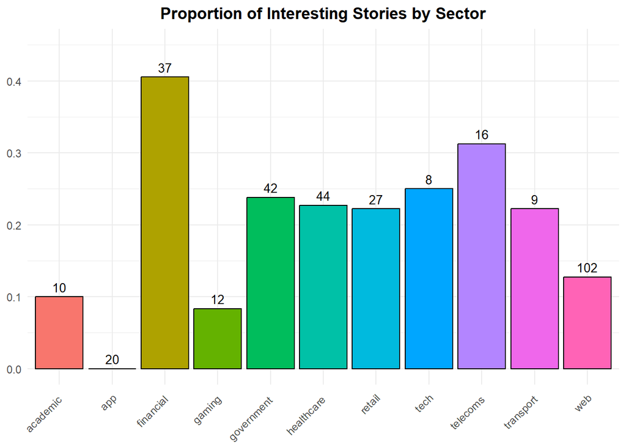

```r
data |>
  group_by(sector) |>
  summarize(prop_interesting = mean(ifelse(interesting_story == 'Yes', 1, 0)),
            N = n()) |>
  filter(N >= 5) |>
  ggplot(aes(x = sector, y = prop_interesting, fill = sector)) +
  geom_col(color = 'black') +
  geom_text(aes(label = N), vjust = -0.5, color = 'black', size = 3.5) +
  # scale_fill_manual(values = cbPalette) +
  theme_minimal() +
  labs(title = 'Proportion of Interesting Stories by Sector') +
  theme(plot.title = element_text(hjust = 0.5, face = 'bold'),
        legend.position = 'none',
        axis.title = element_blank(),
        axis.text.x = element_text(angle = 45, hjust = 1.1, vjust = 1)) +
  ylim(0,0.45)
```

**What is the size of the breach across sectors?**

The breach size does not appear to be the driving factor in the prominence of the financial and telecoms sectors. On second thought, this makes sense. Our Mann-Whitney U test did not show a significant difference in the distributions of records lost in the “Interesting” vs. “Not Interesting” story groups.

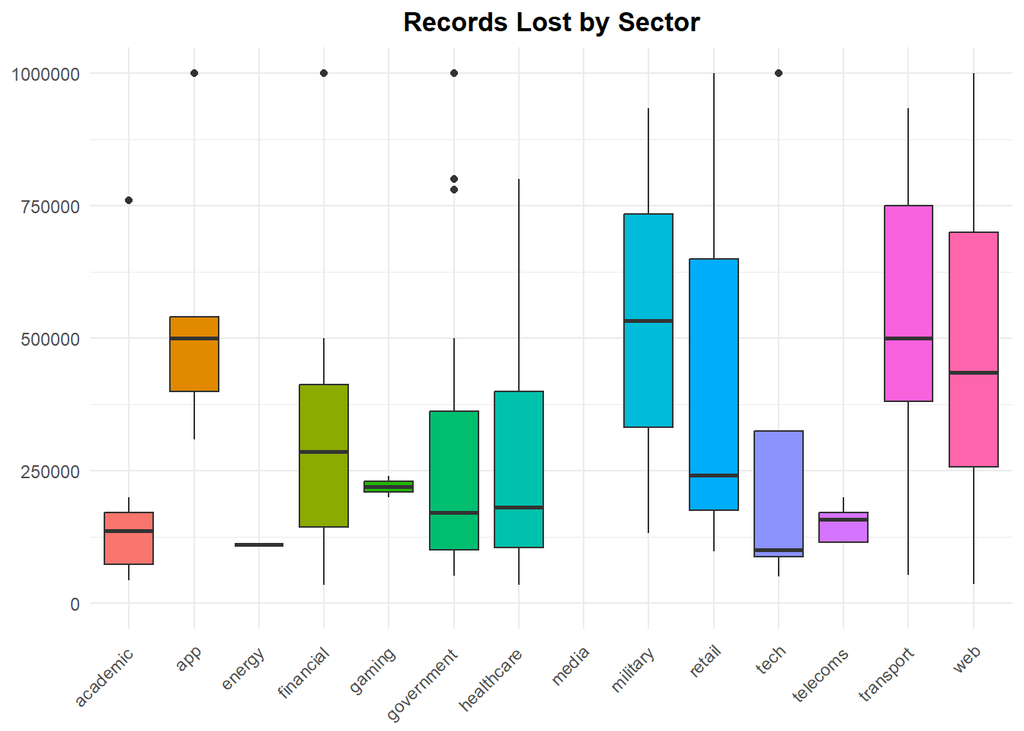

```r
data |>
  ggplot(aes(x = sector, y = records_lost, fill = sector)) +
  geom_boxplot() +
  ylim(0, 1000000) +


  # scale_fill_manual(values = cbPalette) +
  theme_minimal() +
  labs(title = 'Records Lost by Sector') +
  theme(plot.title = element_text(hjust = 0.5, face = 'bold'),
        legend.position = 'none',
        axis.text.x = element_text(angle = 45, hjust = 1.1, vjust = 1),
        axis.title = element_blank())
```

**Perhaps it is the type of information lost or the method that makes these sectors prominent?**

We are getting a bit more complicated here, with more variables here than we can easily visualize.

Let’s build a logistic model to try to quantify the relationship. Because we don’t have a lot of data to work with, I will select the variables I expect to have the highest correlations and dichotomize sector into finance/telecom vs. other.

```r
data <- data |>
          mutate(finance_telecom = factor(ifelse(sector %in% c('financial',
                                                               'telecoms'),
                                                 'Yes', 'No'),
                                          levels = c('No', 'Yes')))

interestingModel_inference <- glm(interesting_story ~ finance_telecom +
                                    data_sensitivity +
                                   records_lost,
                         data = data |> filter(!is.na(records_lost)),
family = 'binomial')



summary(interestingModel_inference)
```

```
Call:
glm(formula = interesting_story ~ finance_telecom + data_sensitivity +
    records_lost, family = "binomial", data = filter(data, !is.na(records_lost)))

Coefficients:
                          Estimate      Std. Error z value        Pr(>|z|)
(Intercept)        -1.957159988416  0.296200769892  -6.608 0.0000000000391 ***
finance_telecomYes  1.053348513744  0.343537392300   3.066        0.002168 **
data_sensitivity2   0.607134719244  0.374773909380   1.620        0.105232
data_sensitivity3   0.390024384502  0.456512871155   0.854        0.392908
data_sensitivity4   0.095840823498  0.479562888597   0.200        0.841598
data_sensitivity5   1.746080893252  0.504408519020   3.462        0.000537 ***
records_lost       -0.000000002031  0.000000001933  -1.051        0.293280
---
Signif. codes:  0 '***' 0.001 '**' 0.01 '*' 0.05 '.' 0.1 ' ' 1

(Dispersion parameter for binomial family taken to be 1)

    Null deviance: 338.48  on 335  degrees of freedom
Residual deviance: 312.65  on 329  degrees of freedom
AIC: 326.65

Number of Fisher Scoring iterations: 5
```

```r
# Calculate Pseudo R-squared to check model fit - higher is better

logisticPseudoR2s <- function(LogModel) {
  dev <- LogModel$deviance
  nullDev <- LogModel$null.deviance
  modelN <- length(LogModel$fitted.values)
  R.l <- 1 - dev / nullDev
  R.cs <- 1 - exp( -(nullDev - dev) / modelN)
  R.n <- R.cs / (1 - ( exp (-(nullDev / modelN))))
  cat('Pseudo R-squared for logistic regression\n')
  cat('Hosmer/Lemeshow:', round(R.l, 3), '\n')
  cat('Cox & Snell:', round(R.cs, 3), '\n')
  cat('Nagelkerke:', round(R.n, 3), '\n')
}

logisticPseudoR2s(interestingModel_inference)
```

```
Pseudo R-squared for logistic regression
Hosmer/Lemeshow: 0.076
Cox & Snell: 0.074
Nagelkerke: 0.117
```

It appears that even when controlling for data sensitivity and records lost the financial and telecom industries are over-represented in the “interesting stories” category. Perhaps this is related to the relative prominence of these industries in publications.

The code for checking the validity of the model can be found in the appendix.

# 5 DS Technique

Now that we have a sense of the relationship between our variables and whether a story is interesting or not, let’s build two models to predict the likelihood of a breach being noted as interesting. First, we will adjust our linear model to be suitable for prediction. Then, we will compare its performance to a random forest model.

```r
# Logistic model

log_model <-
  logistic_reg() |>
  set_engine('glm')

log_wflow <-
  workflow() |>
  add_formula(
    interesting_story ~ sector + method + data_sensitivity + records_lost) |>
  add_model(log_model)


log_fit <-
  log_wflow |>
  fit(data = data |> filter(!is.na(records_lost)))

# Random forest model
rf_model <-
  rand_forest(trees = 1000) |>
  set_engine('ranger') |>
  set_mode('classification')

rf_wflow <-
  workflow() |>
  add_formula(
    interesting_story ~ sector + method + data_sensitivity + records_lost
  ) |>
  add_model(rf_model)

rf_fit <- rf_wflow |>
  fit(data = data |> filter(!is.na(records_lost)))


set.seed(6501)

data_folds <- vfold_cv(data |> filter(!is.na(records_lost)), v = 10, repeats = 5)


keep_pred <- control_resamples(save_pred = TRUE, save_workflow = TRUE)

log_res <-
  log_wflow |>
  fit_resamples(resamples = data_folds, control = keep_pred)

collect_metrics(log_res)
```

```
# A tibble: 3 × 6
  .metric     .estimator  mean     n std_err .config
  <chr>       <chr>      <dbl> <int>   <dbl> <chr>
1 accuracy    binary     0.792    50 0.0114  Preprocessor1_Model1
2 brier_class binary     0.162    50 0.00727 Preprocessor1_Model1
3 roc_auc     binary     0.654    50 0.0203  Preprocessor1_Model1
```

```r
rf_res <-
  rf_wflow |>
  fit_resamples(resamples = data_folds, control = keep_pred)

collect_metrics(rf_res)
```

```
# A tibble: 3 × 6
  .metric     .estimator  mean     n std_err .config
  <chr>       <chr>      <dbl> <int>   <dbl> <chr>
1 accuracy    binary     0.784    50 0.00975 Preprocessor1_Model1
2 brier_class binary     0.164    50 0.00598 Preprocessor1_Model1
3 roc_auc     binary     0.630    50 0.0159  Preprocessor1_Model1
```

In this case, our linear model has slightly outperformed its nonparametric counterpart. This is not a huge surprise with such a small dataset. Because model performance is so similar, I recommend using the linear model for a few reasons:

- It is much faster to retrain and deploy.
- Interpretable coefficients make it easier to understand which factors are most important.
- It is less likely to overfit on retraining.

However, it would be worth looking at more ensemble models if we obtained a larger dataset. In general, these models perform better as they obtain more data, and it would allow us to incorporate variables that might be useful like the text component from the “story” variable.

```r
saveRDS(log_fit, 'trained_predictive_logit_model.rds')
```

# 6 Take-Aways

It seems clear that data breaches are becoming more common as time goes on. While no breach is good, those that generate large amounts of negative publicity for an organization can be particularly harmful. Based on the data we have examined today, I would make the following recommendations:

1. Re-examine our current cybersecurity budget. Are we sufficiently staffed to prevent hacks and prevent exploits?
2. Ensure that internal employees and contractors are unable to remove data from their workspaces.
3. Use the predictive model to assess the potential risk of an “interesting” breach based on likely scenarios. Use this information to assess our highest risk scenarios and prioritize their mitigation.

Implementing these recommendations is likely to reduce our risk of breach in general, and our risk of a PR nightmare caused by a breach in particular.

## 6.1 Appendix

The next few items contain code used for checking the validity of my inferential model. It will not be of interest to business users, but is crucial for determining the validity of the inference made above.

```r
## Check residuals

data_res <- data |>
              filter(!is.na(records_lost)) |>
              mutate(predicted.probabilities = fitted(interestingModel_inference),
                     standardized.residuals = rstandard(interestingModel_inference),
                     studentized.residuals = rstudent(interestingModel_inference),
                     dfbeta_int = dfbeta(interestingModel_inference)[1],
                     dfbeta_pred1 = dfbeta(interestingModel_inference)[2],
                     dffit = dffits(interestingModel_inference),
                     leverage = hatvalues(interestingModel_inference))

# Check that no more than 5% of standardized/studentized residuals have
# an absolute value greater than 1.96 and no more than 1% have an
# absolute value greater than 2.58.

data_res |>
  mutate(stan_gt_196 = ifelse(abs(standardized.residuals) > 1.96, 1, 0),
         stud_gt_196 = ifelse(abs(standardized.residuals) > 1.96, 1, 0),
         stan_gt_258 = ifelse(abs(standardized.residuals) > 2.58, 1, 0),
         stud_gt_258 = ifelse(abs(standardized.residuals) > 2.58, 1, 0)) |>
  filter(!is.na(stan_gt_196)) |>
  summarize(stan_196_prop = round(mean(stan_gt_196),2),
            stud_196_prop = round(mean(stud_gt_196),2),
            stan_258_prop = round(mean(stan_gt_258),2),
            stud_258_prop = round(mean(stud_gt_258),2))
```

```
# A tibble: 1 × 4
  stan_196_prop stud_196_prop stan_258_prop stud_258_prop
          <dbl>         <dbl>         <dbl>         <dbl>
1          0.05          0.05             0             0
```

```r
# Check that dfbeta is less than 1 for the intercept and the predictor of
# interest

data_res |>
  select(dfbeta_int, dfbeta_pred1) |>
  unique()
```

```
# A tibble: 1 × 2
  dfbeta_int dfbeta_pred1
       <dbl>        <dbl>
1    0.00439      0.00649
```

```r
# Check that we have at least 10 events per predictor
n <- nrow(data |> filter(!is.na(records_lost)))
events <- data |> filter(!is.na(records_lost)) |>
  summarize(sum(ifelse(interesting_story == 'Yes', 1, 0))) |>
  pull()
predictors <- length(coef(interestingModel_inference)) - 1

events_per_predictor <- events / predictors
print(events_per_predictor)
```

```
[1] 11.33333
```

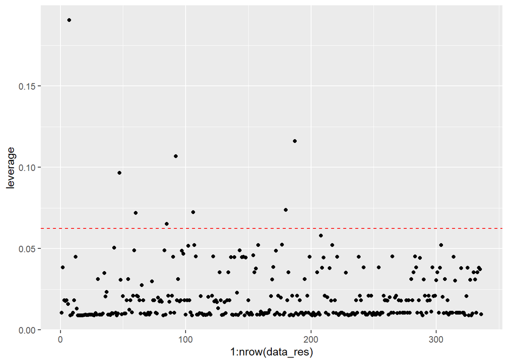

```r
# Plot leverage values - no more than 10% should exceed threshold
ggplot(data_res, aes(x = 1:nrow(data_res), y = leverage)) +
  geom_point() +
  geom_hline(yintercept = 3 * (predictors + 1) / n, linetype = "dashed",
             color = "red")
```

```r
## Check assumptions

# Check that no VIF is over 10

vif(interestingModel_inference)
```

```
                     GVIF Df GVIF^(1/(2*Df))
finance_telecom  1.048596  1        1.024010
data_sensitivity 1.049218  4        1.006024
records_lost     1.000797  1        1.000399
```

```r
# Check the linearity of the logit
# The log_records_lost variable should have a p-value greater than 0.05.

linearity_data <- data |>
                    filter(!is.na(records_lost)) |>
                    mutate(log_records_lost = log(records_lost)*records_lost)

linearityTestModel <- glm(interesting_story ~ sector + method + data_sensitivity + records_lost + as.factor(year) +
                            log_records_lost,
                         data = linearity_data,
                         family = 'binomial')

summary(linearityTestModel)
```

```
Call:
glm(formula = interesting_story ~ sector + method + data_sensitivity +
    records_lost + as.factor(year) + log_records_lost, family = "binomial",
    data = linearity_data)

Coefficients:
                             Estimate        Std. Error z value Pr(>|z|)
(Intercept)          -18.995711635302 3956.180535360993  -0.005 0.996169
sectorapp            -13.907262661079  819.028570508247  -0.017 0.986452
sectorenergy         -13.964120217525 2117.039064072397  -0.007 0.994737
sectorfinancial        2.406759331805    1.263821955904   1.904 0.056865 .
sectorgaming           0.814587215102    1.649677267861   0.494 0.621457
sectorgovernment       1.249835823085    1.251759183835   0.998 0.318055
sectorhealthcare       1.829901208572    1.284401097927   1.425 0.154241
sectormedia            2.363364499900    1.728750949494   1.367 0.171596
sectormilitary         1.989807516216    2.207514248820   0.901 0.367387
sectorretail           1.936077655559    1.296452271304   1.493 0.135341
sectortech             1.709097906329    1.619600754114   1.055 0.291307
sectortelecoms         2.737362148973    1.379497681160   1.984 0.047220 *
sectortransport        2.660225063051    1.502888820613   1.770 0.076715 .
sectorweb              1.472729602164    1.260954830265   1.168 0.242828
methodinside job      -1.338482760160    0.877533738039  -1.525 0.127190
methodlost device      0.338211621303    0.581553102448   0.582 0.560859
methodoops!            1.863754330417    0.663366285527   2.810 0.004961 **
methodpoor security    0.488662565847    0.681371503385   0.717 0.473266
data_sensitivity2      0.355361068052    0.502558224843   0.707 0.479502
data_sensitivity3      0.242985136091    0.610461549566   0.398 0.690604
data_sensitivity4      0.286038757131    0.706420100787   0.405 0.685541
data_sensitivity5      2.807889698416    0.751573929185   3.736 0.000187 ***
records_lost           0.000000170915    0.000000103194   1.656 0.097670 .
as.factor(year)2005   16.440793928955 3956.180621428867   0.004 0.996684
as.factor(year)2006   16.372462001179 3956.180478662965   0.004 0.996698
as.factor(year)2007   15.209996213328 3956.180440605814   0.004 0.996932
as.factor(year)2008   15.899741386718 3956.180390337018   0.004 0.996793
as.factor(year)2009   18.247870896014 3956.180471950142   0.005 0.996320
as.factor(year)2010   15.297112123155 3956.180420527191   0.004 0.996915
as.factor(year)2011   15.106178686733 3956.180400836009   0.004 0.996953
as.factor(year)2012   14.723973502303 3956.180416390714   0.004 0.997030
as.factor(year)2013   16.016967330959 3956.180351385114   0.004 0.996770
as.factor(year)2014   15.458293390925 3956.180394274088   0.004 0.996882
as.factor(year)2015   13.855487451481 3956.180438314338   0.004 0.997206
as.factor(year)2016   12.329680389940 3956.180519908041   0.003 0.997513
as.factor(year)2017   14.471784619003 3956.180451435710   0.004 0.997081
as.factor(year)2018   13.012758130729 3956.180438619536   0.003 0.997376
as.factor(year)2019   14.530581701659 3956.180393106396   0.004 0.997069
log_records_lost      -0.000000008553    0.000000005368  -1.593 0.111072
---
Signif. codes:  0 '***' 0.001 '**' 0.01 '*' 0.05 '.' 0.1 ' ' 1

(Dispersion parameter for binomial family taken to be 1)

    Null deviance: 338.48  on 335  degrees of freedom
Residual deviance: 236.57  on 297  degrees of freedom
AIC: 314.57

Number of Fisher Scoring iterations: 16
```

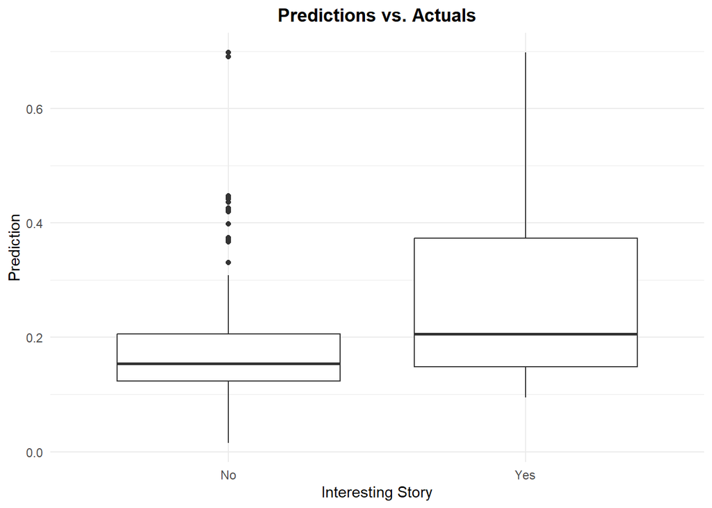

```r
# Plot predictions against actuals

data_res |>
  ggplot(aes(x = interesting_story, y = predicted.probabilities)) +
  geom_boxplot() +
  labs(title = "Predictions vs. Actuals",
       x = "Interesting Story", y = "Prediction") +
  theme_minimal() +
  theme(plot.title = element_text(hjust = 0.5, face = 'bold'))
```